# 231-Final Project-BPM

Ruoyu Li

2022-11-29

```r
library(ggplot2)
library(yardstick)
library(tidymodels)
library(tidyverse)
library(ISLR)
library(ISLR2)
library(glmnet)
library(janitor)
library(corrr)
library(corrplot)
library(rpart.plot)
library(vip)
library(janitor)
library(randomForest)
library(xgboost)
library(dplyr)
tidymodels_prefer(quiet = FALSE)
```

# Introduction

[figure not shown]

In the sports industry, “What makes a great player?” is always a tricky and hard question for anyone to answer. It’s tricky for the fans when they debate endlessly about “Who is the GOAT (Greatest Of All Time)?”. It’s hard for the players because they probably can’t tell what’s their best strength or contribution to the team. It’s difficult for coaches and team managers because when they pick players in the draft each year, they have to decide on which players they should have on their teams.

As for me, I am a basketball fan and a huge fan of NBA (The National Basketball Association), and I personally cannot answer this question well because there are simply so many statistical numbers about those players and you never know which ones are more important than the others. Therefore, in this project, I will use statistical machine learning to investigate data about all drafted NBA players between the year 1989 and 2021. The original dataset contains many information about the NBA career stats of those players, including but not limited to their: overall pick, teams, time played, points, rebounds, assists, field goal percentage etc.

My goal is that I aim to predict the **Box Plus/Minus (BPM)** of a player given his draft pick and other stats. So, this project will mainly address these two questions:

**1. Can we build a good machine learning model that can predict a certain player’s Box Plus/Minus stats? (predictive)**  
**2. For a player’s Box Plus/Minus stats, is the number of overall pick a crucial indicator of it? Or, which of the player’s statistics contributes the most to his Box Plus/Minus? (inferential)**

Before we start, I will first introduce a key terminology here: `Box Plus/Minus`. It is our outcome variable for all the models so it’s good for us to understand what it means and why I believe this is a good statistics to measure a player’s performance/contribution to the team.

A detailed explanation of Box Plus/Minus is available on the website of [Basketball Reference](https://www.basketball-reference.com/about/bpm2.html). But here is a summary of what it means:

**Box Plus/Minus** is a **basketball box score-based metric** that estimates a basketball player’s contribution to the team when that player is on the court. BPM uses a player’s box score information, position, and the team’s overall performance to estimate the player’s contribution in **points above league average per 100 possessions played** (100 is about the number of possessions a team will play in a 48-minute NBA game).

To explain it more clearly, we can take an example of a player A who has a BPM of +5.0. What it means is that we take statistics of all NBA players and suppose there’s an **average player** with a BPM of +0.0. Then we compare the player A with BPM +5.0 to the average player and it tells us that **the presence of player A on the court for 100 possessions will contribute 5 more points compared to the average player**. That’s also why we suppose that the average player has a BPM of +0.0 because 0 is the defined league average for BPM meaning that having an average player on the court is not leading the team to win more points nor causing the team to lose any points.

And we have the following table to give a sense of the scale of BPM:

- +10.0 is an all-time season (think peak Michael Jordan or LeBron James)
- +8.0 is an MVP season (think peak Dirk Nowitzki or peak Shaquille O’Neal)
- +6.0 is an all-NBA season
- +4.0 is in all-star consideration
- +2.0 is a good starter
- +0.0 is a decent starter or solid 6th man
- -2.0 is a bench player (this is also defined as “replacement level”)
- Below -2.0 are many end-of-bench players

We should also note that in this table, +0.0 is a decent starter or solid 6th man instead of a “average player” because in reality, the better players play a lot more time and possessions that the bench players. So, we actually **should have a lot more players with negative BPM than positive BPM**.

After we know what problems we will be working on and what the outcome variable is, we can now do some Exploratory Data Analysis to our raw data file.

# Exploratory Data Analysis

The first thing in my EDA is to read in our raw data, clean the names and look at a summary of it:

```r
setwd("~/Desktop/PSTAT 231/Final project")
nba <- read.csv(file = '~/Desktop/PSTAT 231/Final project/data/nbaplayersdraft.csv')
nba <- clean_names(nba) #use clean_names() to unify the format of all variables
summary(nba) #give a summary of information for all
```

```
##        id              year           rank        overall_pick
##  Min.   :   1.0   Min.   :1989   Min.   : 1.00   Min.   : 1.00
##  1st Qu.: 481.2   1st Qu.:1997   1st Qu.:15.00   1st Qu.:15.00
##  Median : 961.5   Median :2005   Median :30.00   Median :30.00
##  Mean   : 961.5   Mean   :2005   Mean   :29.69   Mean   :29.69
##  3rd Qu.:1441.8   3rd Qu.:2013   3rd Qu.:44.00   3rd Qu.:44.00
##  Max.   :1922.0   Max.   :2021   Max.   :60.00   Max.   :60.00
##
##      team              player            college           years_active
##  Length:1922        Length:1922        Length:1922        Min.   : 1.000
##  Class :character   Class :character   Class :character   1st Qu.: 2.000
##  Mode  :character   Mode  :character   Mode  :character   Median : 5.000
##                                                           Mean   : 6.333
##                                                           3rd Qu.:10.000
##                                                           Max.   :22.000
##                                                           NA's   :253
##      games      minutes_played      points      total_rebounds
##  Min.   :   1   Min.   :    0   Min.   :    0   Min.   :    0
##  1st Qu.:  72   1st Qu.:  838   1st Qu.:  265   1st Qu.:  128
##  Median : 235   Median : 4204   Median : 1552   Median :  656
##  Mean   : 348   Mean   : 8399   Mean   : 3580   Mean   : 1497
##  3rd Qu.: 584   3rd Qu.:13246   3rd Qu.: 5150   3rd Qu.: 2139
##  Max.   :1541   Max.   :52139   Max.   :37062   Max.   :15091
##  NA's   :253    NA's   :253     NA's   :253     NA's   :253
##     assists        field_goal_percentage x3_point_percentage
##  Min.   :    0.0   Min.   :0.0000        Min.   :0.0000
##  1st Qu.:   46.0   1st Qu.:0.4040        1st Qu.:0.2220
##  Median :  257.0   Median :0.4350        Median :0.3170
##  Mean   :  774.3   Mean   :0.4366        Mean   :0.2724
##  3rd Qu.:  910.0   3rd Qu.:0.4740        3rd Qu.:0.3560
##  Max.   :12091.0   Max.   :1.0000        Max.   :1.0000
##  NA's   :253       NA's   :257           NA's   :377
##  free_throw_percentage average_minutes_played points_per_game
##  Min.   :0.0000        Min.   : 0.00          Min.   : 0.000
##  1st Qu.:0.6590        1st Qu.:11.00          1st Qu.: 3.400
##  Median :0.7360        Median :17.70          Median : 6.200
##  Mean   :0.7168        Mean   :18.13          Mean   : 7.276
##  3rd Qu.:0.7970        3rd Qu.:24.80          3rd Qu.:10.000
##  Max.   :1.0000        Max.   :41.10          Max.   :27.200
##  NA's   :289           NA's   :253            NA's   :253
##  average_total_rebounds average_assists   win_shares
##  Min.   : 0.000         Min.   :0.000   Min.   : -1.70
##  1st Qu.: 1.700         1st Qu.:0.500   1st Qu.:  0.40
##  Median : 2.800         Median :1.100   Median :  5.30
##  Mean   : 3.194         Mean   :1.551   Mean   : 17.87
##  3rd Qu.: 4.200         3rd Qu.:2.100   3rd Qu.: 24.50
##  Max.   :13.300         Max.   :9.500   Max.   :249.50
##  NA's   :253            NA's   :253     NA's   :253
##  win_shares_per_48_minutes box_plus_minus    value_over_replacement
##  Min.   :-1.26400          Min.   :-52.000   Min.   : -8.500
##  1st Qu.: 0.03000          1st Qu.: -3.900   1st Qu.: -0.400
##  Median : 0.06900          Median : -2.000   Median :  0.000
##  Mean   : 0.06169          Mean   : -2.311   Mean   :  4.403
##  3rd Qu.: 0.10400          3rd Qu.: -0.300   3rd Qu.:  4.500
##  Max.   : 1.44200          Max.   : 51.100   Max.   :142.600
##  NA's   :254               NA's   :254       NA's   :253
```

By looking at the summary table of all the variables in the raw data, I noticed the following things and decided to make proper data transformations to the raw data:

1. Besides the variables for basic player information, there are some NA values for all other variables such as `years_active`, `games`, `X3_point_percentage` and so on. I believe that the NA values are reasonable because of the following reasons:
- In history, some drafted NBA players actually never played a single game for the NBA, so it’s reasonable that besides their personal information, there is no data for any of their stats. This is also probably true because if we look at all NA values except for `field_goal_percentage`, `x3_point_percentage` and `free_throw_percentage`, they are all 253 or 254, implying that this is about the number of players drafted but never played for NBA.
- For `field_goal_percentage`, `x3_point_percentage` and `free_throw_percentage`, the NA’s are also reasonable because some players might not have a chance to shoot any shots at all. We’ll see later in the EDA that some player stats should be excluded because they played too few games for NBA. The only exceptionally high NA value is for `x3_point_percentage`, which is 377. This can be explained because each basketball player has a position, and before 3-point basket became popular in the 21st century, players at some positions such as center usually never take any 3-point shots.
- After my analysis, and since out dataset has a total of 1922 observations, I decided to **remove the players** that have corresponding NA values because they’re not helpful in my data.
2. There are too many(24) variables in my dataset and some of them are duplicate or not useful for my model, so I decided to **remove some variables** that I will not work with, such as `id`(it’s just the row number),`year`(I don’t want to know when is the player drafted), `college`(I do not want to work with the specific college that the player graduated from),`rank`(it’s duplicate of overall_pick) and `x3_point_percentage`, `free_throw_percentage`(because some players never shoot a 3-point basket or free throw in their career).
3. R took variables like `overall_pick` as numeric variables, so I will **factor** such variables.

```r
nba <- na.omit(nba) # Transformation 1
nba <- select(nba,-c(id,year,college,rank,x3_point_percentage,free_throw_percentage)) #Transformation 2
nba$overall_pick <- factor(nba$overall_pick) #Transformation 3
nrow(nba) #return the number of observations left
```

```
## [1] 1529
```

After the above transformations, we’re left with 1529 observations, which is still a good number, so I will then explore on the outcome variable that I want to work with, `box_plus_minus`.

I will plot a histogram to see its distribution:

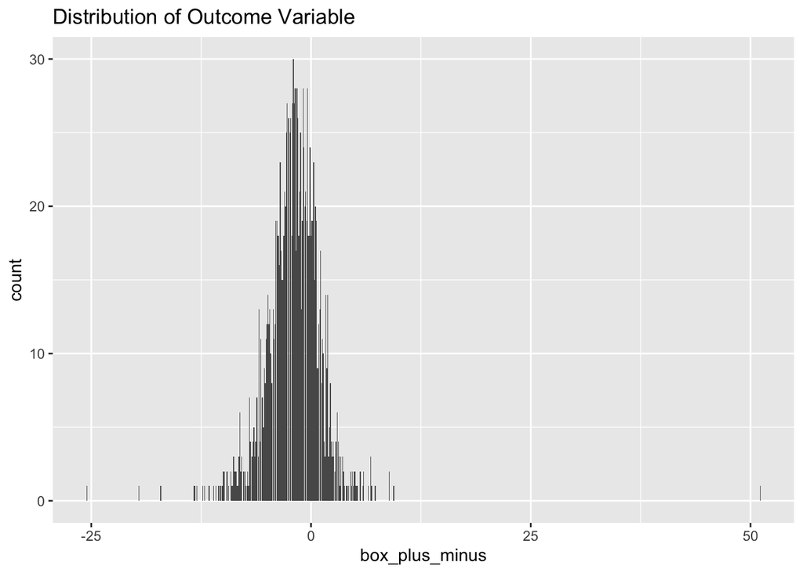

```r
nba %>%
  ggplot(aes(box_plus_minus)) +
  geom_bar() +
  ggtitle('Distribution of Outcome Variable')
```

It looks like a bell-shaped normal distribution, but we can see that there are several obvious outliers one around 50 and another around -25. From our understanding of BPM, these values are definitely not normal. My thought is that there might be some players that played too few games or even too short of time in one game, so their statistics is not NA but is also not representative of their overall ability as well. Therefore, I pulled out the stats for those outlier players as below:

```r
nba[which(nba$box_plus_minus == max(nba$box_plus_minus)),]#extract the row with highest BPM
```

```
##     overall_pick team        player years_active games minutes_played points
## 544           47  TOR Tyson Wheeler            1     1              3      4
##     total_rebounds assists field_goal_percentage average_minutes_played
## 544              0       2                     1                      3
##     points_per_game average_total_rebounds average_assists win_shares
## 544               4                      0               2        0.1
##     win_shares_per_48_minutes box_plus_minus value_over_replacement
## 544                     1.367           51.1                      0
```

```r
nba[which(nba$box_plus_minus == min(nba$box_plus_minus)),]#extract the row with lowest BPM
```

```
##      overall_pick team              player years_active games minutes_played
## 1377           55  DAL Darius Johnson-Odom            2     7             21
##      points total_rebounds assists field_goal_percentage average_minutes_played
## 1377      0              6       2                     0                      3
##      points_per_game average_total_rebounds average_assists win_shares
## 1377               0                    0.9             0.3       -0.3
##      win_shares_per_48_minutes box_plus_minus value_over_replacement
## 1377                    -0.597          -25.5                   -0.1
```

Indeed, I see that they are players who each played only 3 minutes and 21 minutes for NBA, so it’s almost meaningless to take their stats numbers into account for my model because the sample size is simply too small!

Therefore, I decided to *filter* the players and only include the players that have played a reasonable amount of time in the NBA to be considered. In the following chunk, I filter out some players and only kept the ones who have played for at least **2 years** and **50 games** in the NBA. Then, I plotted again the distribution of our outcome variable `box_plus_minus`.

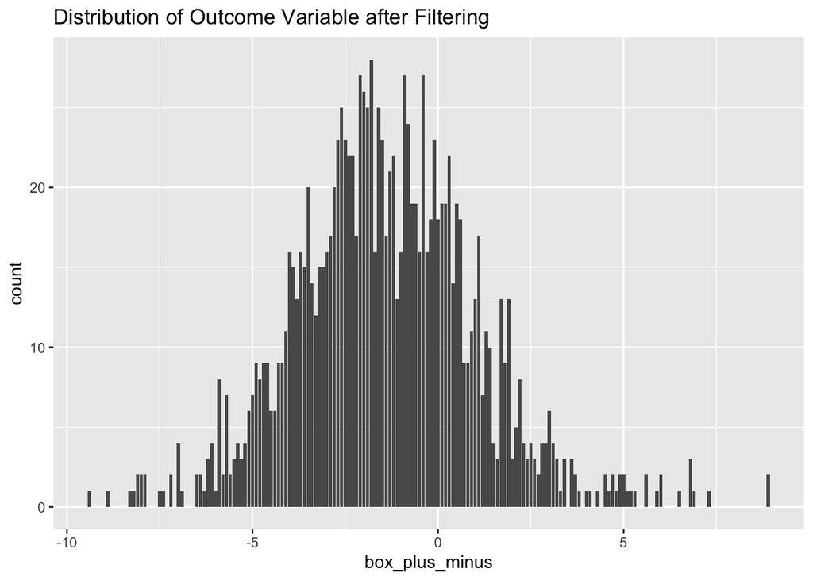

```r
nba <- filter(nba,years_active >= 2 & games >= 50) #filter out the players who played too few for NBA
nba %>%
  ggplot(aes(box_plus_minus)) +
  geom_bar() +
  ggtitle('Distribution of Outcome Variable after Filtering')
```

```r
nrow(nba) #return the number of observations left
```

```
## [1] 1288
```

```r
mean(nba$box_plus_minus) #return the mean of BPM after filtering
```

```
## [1] -1.404891
```

At this point, I can see that the outliers are all gone, and we’re left with 1288 observations. This is still a good amount for me. Moreover, the plot looks a lot more normal and we can see that it’s bell-shaped with mean a little lower than 0.0, which is explained in the measurement of BPM. So now, I think I can keep working with this dataset.

Now, I want to see the correlation between some numeric variables that I am interested in, so I created the following correlation matrix to see the relationships among those variables:

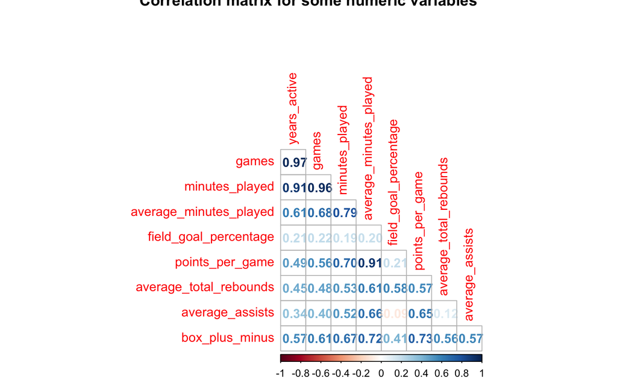

```r
nba %>%
  select(c(overall_pick , years_active, games , minutes_played , average_minutes_played, field_goal_percentage , points_per_game ,
           average_total_rebounds , average_assists, box_plus_minus)) %>%
  select_if(is.numeric) %>%
  cor() %>%
  corrplot(method = 'number', diag = F, type = 'lower', bg = 'white', title = 'Correlation matrix for some numeric variables')
```

From this correlation matrix, there are several things I observed:

1. `games`, `years_active`, `minutes_played` are highly correlated with each other. This makes sense since they are all measurements about the total time a player has played for the NBA. So, when I create my recipe, if I include all of them as predictors because I want their information, I will use Principle Component Analysis and probably extract one principle component from them.
2. For our outcome variable `box_plus_minus`, `average_minutes_played` and `points_per_game` have the highest correlations with it. This result is also comprehensible because BPM basically measures how many points can a player contribute for 100 possessions, and if a player can score more points per game, the player should be given more time to play each game and this would lead to a higher BPM.
3. There ar some other explainable high correlations, such as `points_per_game` and `average_minutes_played`, implying that a player that plays a lot of time each game usually get more points in a game. `points_per_game`/`average_minutes_played` and `average_assists`, implying that a player who sends more dimes also can get more points and playing time etc.

At this point, we have had a good understanding of the outcome variable `box_plus_minus`, and our data is well cleaned up and ready to use, so we are ready to prepare to our models!

# Model Preparation

This is the section that we prepare our data for fitting different models.

## Initial Split

We first split our dataset into training and testing sets according to a 80%-20% split. Remember to set seed here so that we can reproduce the same result each time we run the program.

```r
set.seed(23) #set seed at beginning
nba_split <- initial_split(nba, prop = 0.80, strata = box_plus_minus) #use stratified sampling
nba_train <- training(nba_split)
nba_test <- testing(nba_split)
dim(nba_train)[1]/dim(nba)[1]
```

```
## [1] 0.798913
```

```r
dim(nba_test)[1]/dim(nba)[1]
```

```
## [1] 0.201087
```

And here we also verified that the training and testing data sets have the appropriate number of observations.

## Create recipe

Then we create the recipe for our model. I used 8 predictors in total to predict `box_plus_minus`, they are `team`, `overall_pick`, `years_active`, `games`, `field_goal_percentage`, `points_per_game`, `average_total_rebounds` and `average_assists`.

I am more interested in using a player’s efficiency to determine his Box Plus/Minus, so I used for example `points_per_game` instead of `points` as predictor in my recipe. I also dummy coded all nominal predictors and normalized all predictors. Also as mentioned before, I used step_pca() to extract one principle component from predictors `games` and `years_active`, and this one principle component should give me a reflection of the total playing time of players.

```r
nba_recipe <-
  recipe(box_plus_minus ~ team + overall_pick + years_active + games + field_goal_percentage + points_per_game + average_total_rebounds + average_assists, data = nba_train) %>%
  step_dummy(all_nominal_predictors()) %>% #dummy code nominal predictors
  step_normalize(all_predictors()) %>% #normalize all predictors
  step_pca(years_active,games,num_comp = 1) %>% #principle component analysis
  step_zv(all_predictors()) #remove variables that contain only a single value (for scaling)
```

## Cross-Validation

We also need to fold the training set using *k*-fold cross-validation, with `k = 5`. Stratify on the outcome variable.

What cross-validation helps us is that it is an important resampling method used in machine learning. We should use it because k-fold cross-validation helps us to randomly divide the data into k folds(groups), and then each of the fold is held as the validation set and we fit the model on the remaining k-1 folds and repeat for k times. This helps us to utilize the data as much as possible and get a better estimate of the $R^2$. If we simply fit and test models on the entire training set, then we’re essentially testing our model using the data we trained it with, so we don’t know how well it will perform on new data.

```r
nba_folds <- vfold_cv(nba_train, v = 5, strata = box_plus_minus) #use stratified sampling
```

# Fitting and tuning different models

Here I will try to fit the following models to our 5-fold training data and see which one performs the best in terms of $R^2$ value:

Here is just to remind that $R^2$ is a measure of proportion of the variability in Y(outcome variable) that can be explained using X(predictors). It’s a value between 0 and 1 and usually the higher $R^2$ is,the better our model fits the data. Since our problem would be an regression problem, I will use this metric to evaluate the performance of each model.

## Linear Regression

The first model we use is a simple linear regression model. It works as follows:

```r
lm_model <- linear_reg() %>% #setting up the model
  set_engine("lm")

lm_wkflow <- workflow() %>% #setting up the workflow
  add_model(lm_model) %>%
  add_recipe(nba_recipe)

lm_fit_cv <- fit_resamples(lm_wkflow, resamples = nba_folds) #fit the model in the 5 folds of training data

collect_metrics(lm_fit_cv)#use collect_metrics() to see the R^2 value of our model.
```

```
## # A tibble: 2 × 6
##   .metric .estimator  mean     n std_err .config
##   <chr>   <chr>      <dbl> <int>   <dbl> <chr>
## 1 rmse    standard   1.44      5  0.0289 Preprocessor1_Model1
## 2 rsq     standard   0.662     5  0.0194 Preprocessor1_Model1
```

We can see that our simplest linear regression model gives us a mean $R^2$ value of 0.6616494 , this is a not bad $R^2$ value saying that about 66% of the variability of BPM can be explained by our model. However, we are not sure if we would have the problem of overfitting in linear regression, so I will choose to integrate some penalty term in our model and use Elastic Net tuning method to find a regularized regression model for our data.

## Elastic Net Tuning

Here is our regularized regression model:

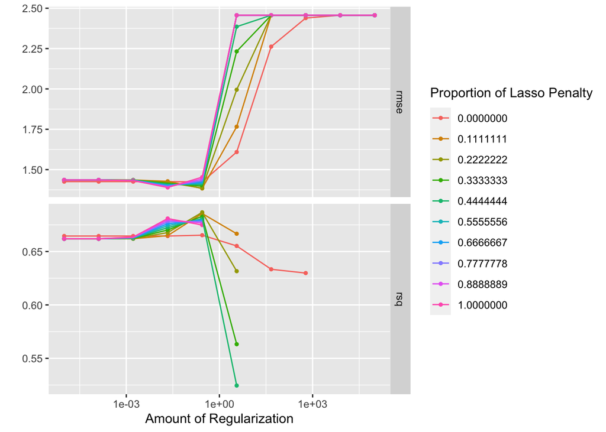

```r
elastic_net <-linear_reg(penalty = tune(), mixture = tune()) %>% #set up the model, tune penalty and mixture
  set_mode("regression") %>%
  set_engine("glmnet")

elastic_net_workflow <- workflow() %>% #setting up the workflow
  add_recipe(nba_recipe) %>%
  add_model(elastic_net)
#create regular grid for tuning
elastic_net_grid <- grid_regular(penalty(range = c(-5, 5)), mixture(range = c(0,1)), levels = 10)

en_tune_res <- tune_grid(
  elastic_net_workflow,
  resamples = nba_folds,
  grid = elastic_net_grid
)

autoplot(en_tune_res) #visualize the results of our model
```

```r
write_rds(en_tune_res, file = '~/Desktop/PSTAT 231/Final project/R_scripts/elastic_net.rds')
```

From the plot above, we can see that in terms of $R^2$, its value first increase by a little then decrease quickly if we increase the amount of regularization. For the proportion of Lasso Penalty or mixture, the difference is not clear but in terms of RMSE, we can see that the pure lasso regression model tends to have higher RMSE. We can check to see which one is our best-performing elastic tuning model here:

```r
show_best(en_tune_res, metric = "rsq",1) %>% select(-.estimator, -.config)
```

```
## # A tibble: 1 × 6
##   penalty mixture .metric  mean     n std_err
##     <dbl>   <dbl> <chr>   <dbl> <int>   <dbl>
## 1   0.278   0.222 rsq     0.687     5  0.0171
```

Here we have a $R^2$ value of 0.6866934 when penalty is 0.2782559 and mixture is 0.2222222, which is slightly better than the linear regression model that we have. Now, we will turn from linear models to test some tree-based models:

## Regression Tree

The first tree-based the model that I will try is a regression tree, it’s a decision tree model and it’s good that we can see how it makes decisions at each step. I will tune the `cost_complexity` of the decision tree, or the pruning penalty, to find a more optimal complexity. Firstly, I’ll fit the model and see what’s the best $R^2$ value we can get from the pruned tree..

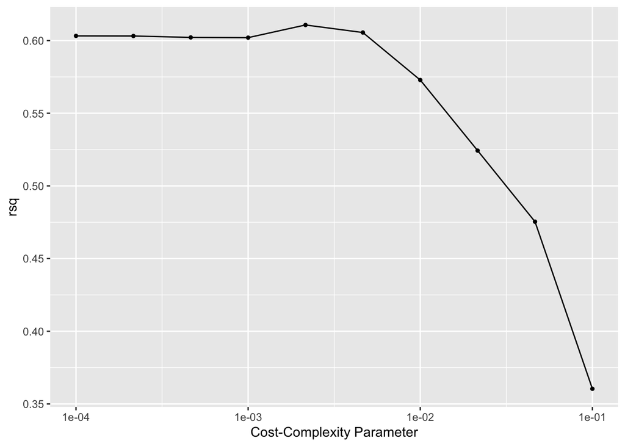

```r
tree_spec <- decision_tree() %>% #set up model
  set_engine("rpart") %>%
  set_mode("regression")

reg_tree_wf <- workflow() %>% #set up workflow
  add_model(tree_spec %>% set_args(cost_complexity = tune())) %>% #we will tune the cost_complexity here
  add_recipe(nba_recipe)

param_grid <- grid_regular(cost_complexity(range = c(-4, -1)), levels = 10) #regular grid for tuning

reg_tree_tune_res <- tune_grid(
  reg_tree_wf,
  resamples = nba_folds,
  grid = param_grid,
  metrics = metric_set(rsq)
)

write_rds(reg_tree_tune_res, file = '~/Desktop/PSTAT 231/Final project/R_scripts/regression_tree.rds')

autoplot(reg_tree_tune_res) #plot the result at different cost_complexity levels
```

We can see that as the Cost-Complexity increases, the $R^2$ value first increases a bit but then deceases quickly. We cans ee our best performing tuned model here:

```r
head(arrange(collect_metrics(reg_tree_tune_res), desc(mean)),1) #get the R^2 value for our best model
```

```
## # A tibble: 1 × 7
##   cost_complexity .metric .estimator  mean     n std_err .config
##             <dbl> <chr>   <chr>      <dbl> <int>   <dbl> <chr>
## 1         0.00215 rsq     standard   0.611     5  0.0184 Preprocessor1_Model05
```

At Cost-Complexity level 0.002154435, we have reached the highest $R^2$ value of 0.610724, which isn’t that good compared to the above linear models, but it’s useful that we can used a decision tree model and plot how it makes the decision at each step below:

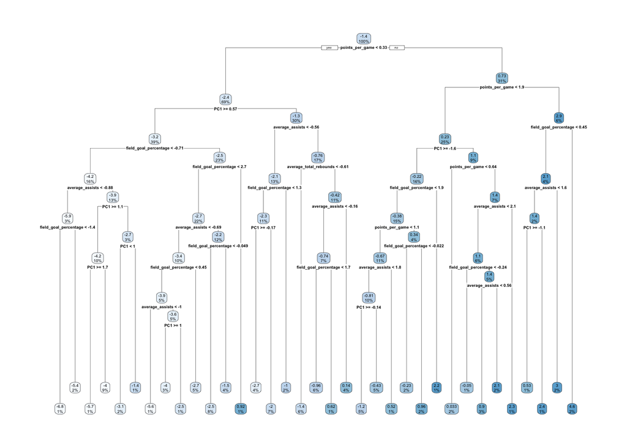

```r
regression_tree <- read_rds(file = '~/Desktop/PSTAT 231/Final project/R_scripts/regression_tree.rds')

rt_best_model <- select_best(regression_tree)

reg_tree_final <- finalize_workflow(reg_tree_wf, rt_best_model)

reg_tree_final_fit <- fit(reg_tree_final, data = nba_train)

reg_tree_final_fit %>%
  extract_fit_engine() %>%
  rpart.plot()
```

## Random Forest

Now beyond a single decision tree, I will fit a random forest model for tuning as well. Here I tuned three parameters:`mtry` is an integer for the number of predictors that will be randomly sampled at each split when creating the tree models.`Trees` is an integer for the number of trees to be fit to the model. `Min_n` is an integer for the minimum number of data points in a node that are required for the node to be split further. I tuned `mtry` from 1 to 8, the rule of thumb is we take `p/3` variables when building a random forest of regression trees, but since we only have 8 predictors here I just set to the maximum of 8.

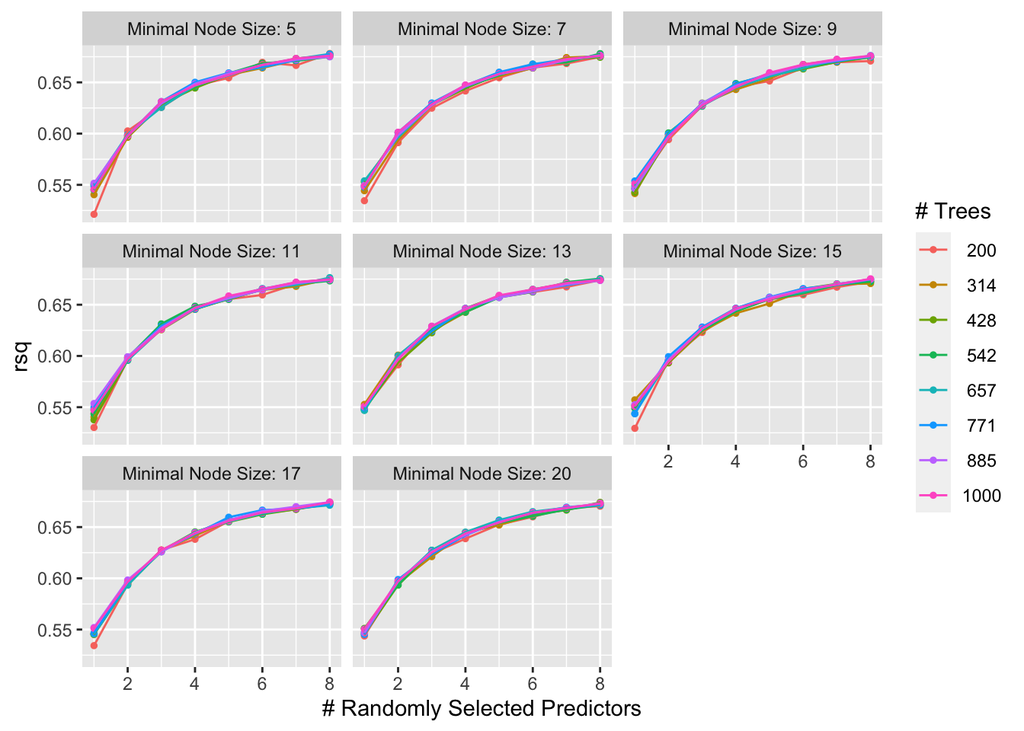

```r
rf_spec <- rand_forest(mtry = tune(), trees = tune(), min_n = tune()) %>%
  set_engine("ranger", importance = "impurity") %>% #set up model
  set_mode("regression")

rf_wf <- workflow() %>% #set up workflow
  add_model(rf_spec) %>%
  add_recipe(nba_recipe)

rf_grid <- grid_regular(mtry(range = c(1,8)), #create regular grid for tuning 3 parameters
                           min_n(range = c(5,20)),
                           trees(range = c(200,1000)), levels = 8)

rf_tune_res <- tune_grid(
  rf_wf,
  resamples = nba_folds,
  grid = rf_grid,
  metrics = metric_set(rsq)
)

write_rds(rf_tune_res, file = '~/Desktop/PSTAT 231/Final project/R_scripts/random_forest.rds')

autoplot(rf_tune_res) #visualize the results
```

From the plots above, we can see that the $R^2$ value typically increases when we increase `mtry`, the number of randomly selected predictors. Also, minimum node size and number of trees don’t seem to affect the $R^2$ value a lot.

Now I will see which one is our best tuned random forest model:

```r
random_forest <- read_rds(file = '~/Desktop/PSTAT 231/Final project/R_scripts/random_forest.rds')
rf_res <- arrange(collect_metrics(random_forest), desc(mean))
head(rf_res,1)
```

```
## # A tibble: 1 × 9
##    mtry trees min_n .metric .estimator  mean     n std_err .config
##   <int> <int> <int> <chr>   <chr>      <dbl> <int>   <dbl> <chr>
## 1     8   200     5 rsq     standard   0.678     5  0.0134 Preprocessor1_Model0…
```

Here we can see that for our random forest models, the best one reached a $R^2$ value of 0.678146, with `mtry` = 8, `trees` = 200 and `min_n` = 5. It is in general a not bad $R^2$ value.

## Boosted Trees

Finally, I will tune a boosted tree model to my data here, I will tune two parameters:`trees`,`tree_depth`, which are the number of trees it can grow and the maximum depth of our model.

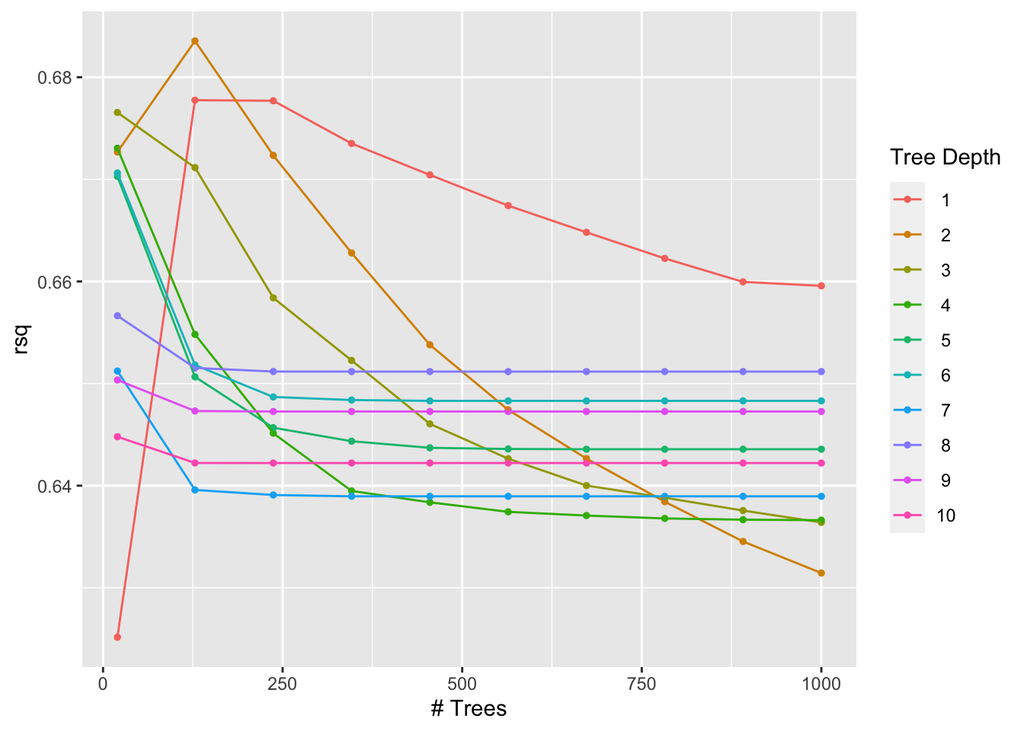

```r
boost_spec <- boost_tree() %>%
  set_engine("xgboost") %>%
  set_mode("regression")

boost_wf <- workflow() %>%
  add_model(boost_spec %>% set_args(trees = tune(),tree_depth =tune())) %>%
  add_recipe(nba_recipe)

boost_grid <- grid_regular(trees(range = c(20,1000)),
                           tree_depth(range = c(1,10)),
                           levels = 10)

boost_tune_res <- tune_grid(
  boost_wf,
  resamples = nba_folds,
  grid = boost_grid,
  metrics = metric_set(rsq)
)

write_rds(boost_tune_res, file = '~/Desktop/PSTAT 231/Final project/R_scripts/boost_tree.rds')

autoplot(boost_tune_res)
```

From the plot, we can see that for most tree depths, the $R^2$ value tends to go down as we increase the number of trees, as we know this might be because of overfitting. And it’s quite clear from the plot that the best performing model is tree_depth = 2 and we can find it here:

```r
boost_tree <- read_rds(file = '~/Desktop/PSTAT 231/Final project/R_scripts/boost_tree.rds')
bt_res <- arrange(collect_metrics(boost_tree), desc(mean))
head(bt_res,1)
```

```
## # A tibble: 1 × 8
##   trees tree_depth .metric .estimator  mean     n std_err .config
##   <int>      <int> <chr>   <chr>      <dbl> <int>   <dbl> <chr>
## 1   128          2 rsq     standard   0.684     5  0.0156 Preprocessor1_Model012
```

We can see that our best boosted tree model have an $R^2$ value of 0.6835549 when `trees` = 128 and `tree_depth` = 2, which is a not bad $R^2$ value as well.

# Final Model Building and Selection

After I fitted and tuned all the above models, I found the best tuning parameters for each model and I will next fit each of the best models to the entire training dataset and compare their performances.

## Linear Regression Final

```r
#select the best model
lm_best_model <- select_best(lm_fit_cv, metric = "rsq")
#create a finalized workflow
lm_final <- finalize_workflow(lm_wkflow, lm_best_model)
#fit our best model to the entire training set
lm_final_fit <- fit(lm_final, data = nba_train)
#get the R^2 value for our final model fitting on the training set
augment(lm_final_fit, new_data = nba_train) %>%
  rsq(truth = box_plus_minus, estimate = .pred)
```

```
## # A tibble: 1 × 3
##   .metric .estimator .estimate
##   <chr>   <chr>          <dbl>
## 1 rsq     standard       0.733
```

## Elastic Net Final

```r
elstic_net <- read_rds(file = '~/Desktop/PSTAT 231/Final project/R_scripts/elastic_net.rds')
#select the best model
en_best_model <- select_best(elstic_net, metric = "rsq")
#create a finalized workflow
elastic_net_final <- finalize_workflow(elastic_net_workflow, en_best_model)
#fit our best model to the entire training set
elastic_net_final_fit <- fit(elastic_net_final, data = nba_train)
#get the R^2 value for our final model fitting on the training set
augment(elastic_net_final_fit, new_data = nba_train) %>%
  rsq(truth = box_plus_minus, estimate = .pred)
```

```
## # A tibble: 1 × 3
##   .metric .estimator .estimate
##   <chr>   <chr>          <dbl>
## 1 rsq     standard       0.704
```

## Regression Tree Final

```r
#select the best model
rt_best_model <- select_best(reg_tree_tune_res, metric = "rsq")
#create a finalized workflow
rt_final <- finalize_workflow(reg_tree_wf, rt_best_model)
#fit our best model to the entire training set
rt_final_fit <- fit(rt_final, data = nba_train)
#get the R^2 value for our final model fitting on the training set
augment(rt_final_fit, new_data = nba_train) %>%
  rsq(truth = box_plus_minus, estimate = .pred)
```

```
## # A tibble: 1 × 3
##   .metric .estimator .estimate
##   <chr>   <chr>          <dbl>
## 1 rsq     standard       0.740
```

## Random Forest Final

```r
random_forest <- read_rds(file = '~/Desktop/PSTAT 231/Final project/R_scripts/random_forest.rds')
#select the best model
best_rf <- select_best(random_forest)
#create a finalized workflow
rf_final <- finalize_workflow(rf_wf, best_rf)
#fit our best model to the entire training set
rf_final_fit <- fit(rf_final, data = nba_train)
#get the R^2 value for our final model fitting on the training set
augment(rf_final_fit, new_data = nba_train) %>%
  rsq(truth = box_plus_minus, estimate = .pred)
```

```
## # A tibble: 1 × 3
##   .metric .estimator .estimate
##   <chr>   <chr>          <dbl>
## 1 rsq     standard       0.909
```

## Boosted Tree Final

```r
#select the best model
bt_best_model <- select_best(boost_tune_res, metric = "rsq")
#create a finalized workflow
bt_final <- finalize_workflow(boost_wf, bt_best_model)
#fit our best model to the entire training set
bt_final_fit <- fit(bt_final, data = nba_train)
#get the R^2 value for our final model fitting on the training set
augment(bt_final_fit, new_data = nba_train) %>%
  rsq(truth = box_plus_minus, estimate = .pred)
```

```
## # A tibble: 1 × 3
##   .metric .estimator .estimate
##   <chr>   <chr>          <dbl>
## 1 rsq     standard       0.845
```

We can make a table to see which model performs the best here:

```r
r_squared <- c(0.733101 , 0.7038161 , 0.7396775 , 0.9059735, 0.8447882      )
models <- c("Linear Regression", "Elastic Net", "Regression Tree", "Random Forest", "Boosted Tree")
results <- tibble(r_squared = r_squared, models = models)
results %>%
  arrange(-r_squared)
```

```
## # A tibble: 5 × 2
##   r_squared models
##       <dbl> <chr>
## 1     0.906 Random Forest
## 2     0.845 Boosted Tree
## 3     0.740 Regression Tree
## 4     0.733 Linear Regression
## 5     0.704 Elastic Net
```

In general, from our table, we can also see that the tree-based models performed better and more complex tree-based models like random forest and boosted trees performed better than single decision tree. Also, the linear models performed relatively poorly, that’s probably because the mechanism of BPM doesn’t really follow the linear assumptions.

Now we will use this model to fit on the testing data and see how it performs:

# Final Fitting To Testing Set

Finally, after we select our best-performing random forest model on the entire training set, I will fit it on the testing test and see how well it performs:

```r
rf_final_fit_test <- fit(rf_final, data = nba_test)
augment(rf_final_fit_test, new_data = nba_test) %>%
  rsq(truth = box_plus_minus, estimate = .pred)
```

```
## # A tibble: 1 × 3
##   .metric .estimator .estimate
##   <chr>   <chr>          <dbl>
## 1 rsq     standard       0.921
```

Here we can also visualize the results of our model by plotting the true values against the predicted values:

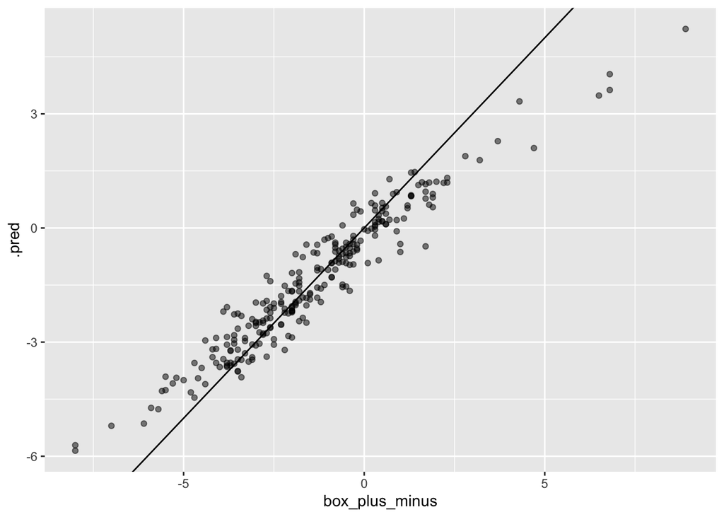

```r
augment(rf_final_fit_test, new_data = nba_test) %>%
  ggplot(aes(box_plus_minus, .pred)) +
  geom_abline() +
  geom_point(alpha = 0.5)
```

We can see that most points are either on the line or pretty close to it, so our model is good!

# Conclusion

In the introduction, I mentioned that this project will mainly focuses on two questions:

1. Can we build a good machine learning model that can predict a certain player’s Box Plus/Minus stats? (predictive)
2. For a player’s Box Plus/Minus stats, is the number of overall pick a crucial indicator of it? Or, which of the player’s statistics contributes the most to his Box Plus/Minus? (inferential)

To address the second question of this project, I will first plot a **variable importance plot** using our random forest model:

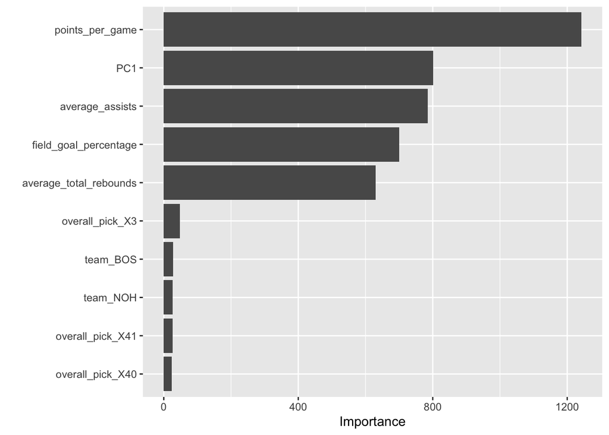

```r
rf_final_fit %>% #final fit using training dataset
  extract_fit_engine() %>% #I used training here because the model is fitted on the training data
  vip()
```

We can observe from this graph that for our prediction of `Box Plus/Minus`, the most important variables are `points_per_game`, `PC1`, `average_assists`, `average_total_rebounds` and `field_goal_percentage`. The other predictors are of relatively much lower importance and it’s obvious that `overall_pick` doesn’t play a huge role in this model!

Therefore, **for the second question**, we reached the conclusion that the number of `overall_pick` is **not** a crucial indicator of prediction of **Box Plus/Minus**. The crucial indicators are `points_per_game`, `PC1`(basically says the total career playing time of player), `average_assists`, `average_total_rebounds` and `field_goal_percentage`. So, it says that even if you are #1 over all pick, don’t sleep on that because that doesn’t mean you can become a great player! And if you are drafted behind others, don’t give up and you can still have a great career! And it says that if you want a higher Box Plus/Minus, you need to get more points each game, have a longer career, and then put on all the assists, rebounds and field goal percentage statistics as well!

Finally, let’s go LeBron James! The NBA GOAT in my opinion!

[figure not shown]